# Overview

The `adaptr` package simulates adaptive (multi-arm, multi-stage) clinical trials using adaptive stopping, adaptive arm dropping and/or response-adaptive randomisation.

The package has been developed as part of the [INCEPT (Intensive Care Platform Trial) project](https://incept.dk/), funded primarily by a grant from [Sygeforsikringen “danmark”](https://www.sygeforsikring.dk/).

Additional guidance on the key methodological considerations when planning and comparing adaptive clinical trials can be found in the open access article *“[An overview of methodological considerations regarding adaptive stopping, arm dropping and randomisation in clinical trials](https://doi.org/10.1016/j.jclinepi.2022.11.002)”* available in Journal of Clinical Epidemiology.

## Basic example

First, load the package:

```r
library(adaptr)
```

Parallelisation is supported in many `adaptr` functions, and a cluster of parallel workers may be setup for the entire session using `setup_cluster()`, which is ideally called early in a script. Alternatively, parallelisation can be controlled by the global `"mc.cores"` option (set by calling `options(mc.cores = <number>)`) or the `cores` argument of many functions.

### Set up trial

Then, setup a trial with the desired specifications. `adaptr` offers the general purpose function `setup_trial()`, but here we use the built-in `setup_trial_binom()` for a trial with a binary, binomially distributed, undesirable outcome such as mortality (`adaptr` also includes `setup_trial_norm()` for continuous, normally distributed outcomes).

The example trial specification has the following characteristics:

- The allocation probability to each arm cannot be lower than 15% (`min_probs`).
- Default thresholds for `inferiority` (< 1% probability of being the best arm) and `superiority` (> 99% probability of being the best arm) are used and hence not specified.
- Equivalence stopping rule: if the simulation yields a 90% probability (`equivalence_prob`) of treatment differences being < 5 %-points (`equivalence_diff`), the trial is stopped.
- We soften allocation ratios (`soften_power`) by a constant factor.

```r
binom_trial <- setup_trial_binom(
  arms = c("Arm A", "Arm B", "Arm C"),
  true_ys = c(0.25, 0.20, 0.30),
  min_probs = rep(0.15, 3),
  data_looks = seq(from = 300, to = 2000, by = 100),
  equivalence_prob = 0.9,
  equivalence_diff = 0.05,
  soften_power = 0.5
)
```

See `?setup_trial()` for more details on the arguments or `vignette("Basic-examples", "adaptr")` for **basic** example trial specifications and a thorough review of the general trial specification settings, and `vignette("Advanced-example", "adaptr")` for an **advanced** example including details on how to specify user-written functions for generating outcomes and posterior draws.

We can print an overview of the trial specification by simply running:

```r
binom_trial
```

```
#> Trial specification: generic binomially distributed outcome trial
#> * Undesirable outcome
#> * No common control arm
#> * Best arm: Arm B
#>
#> Arms, true outcomes, starting allocation probabilities
#> and allocation probability limits:
#>   arms true_ys start_probs fixed_probs min_probs max_probs
#>  Arm A    0.25       0.333          NA      0.15        NA
#>  Arm B    0.20       0.333          NA      0.15        NA
#>  Arm C    0.30       0.333          NA      0.15        NA
#>
#> Maximum sample size: 2000
#> Maximum number of data looks: 18
#> Planned data looks after:  300, 400, 500, 600, 700, 800, 900, 1000, 1100, 1200, 1300, 1400, 1500, 1600, 1700, 1800, 1900, 2000 patients have reached follow-up
#> Number of patients randomised at each look:  300, 400, 500, 600, 700, 800, 900, 1000, 1100, 1200, 1300, 1400, 1500, 1600, 1700, 1800, 1900, 2000
#>
#> Superiority threshold: 0.99 (all analyses)
#> Inferiority threshold: 0.01 (all analyses)
#> Equivalence threshold: 0.9 (all analyses) (no common control)
#> Absolute equivalence difference: 0.05
#> No futility threshold (not relevant - no common control)
#> Soften power for all analyses: 0.5
```

By default, (most) probabilities are shown with 3 decimals. This can be changed by explicitly `print()`ing the specification with the `prob_digits` arguments, for example:

```r
print(binom_trial, prob_digits = 2)
```

```
#> Trial specification: generic binomially distributed outcome trial
#> * Undesirable outcome
#> * No common control arm
#> * Best arm: Arm B
#>
#> Arms, true outcomes, starting allocation probabilities
#> and allocation probability limits:
#>   arms true_ys start_probs fixed_probs min_probs max_probs
#>  Arm A    0.25        0.33          NA      0.15        NA
#>  Arm B    0.20        0.33          NA      0.15        NA
#>  Arm C    0.30        0.33          NA      0.15        NA
#>
#> Maximum sample size: 2000
#> Maximum number of data looks: 18
#> Planned data looks after:  300, 400, 500, 600, 700, 800, 900, 1000, 1100, 1200, 1300, 1400, 1500, 1600, 1700, 1800, 1900, 2000 patients have reached follow-up
#> Number of patients randomised at each look:  300, 400, 500, 600, 700, 800, 900, 1000, 1100, 1200, 1300, 1400, 1500, 1600, 1700, 1800, 1900, 2000
#>
#> Superiority threshold: 0.99 (all analyses)
#> Inferiority threshold: 0.01 (all analyses)
#> Equivalence threshold: 0.9 (all analyses) (no common control)
#> Absolute equivalence difference: 0.05
#> No futility threshold (not relevant - no common control)
#> Soften power for all analyses: 0.5
```

Finally, a trial specification may be calibrated to obtain a specific value for a certain performance metric (e.g., the Bayesian type 1 error rate for trial specifications with no between-arm differences; not done in this overview) by using the `calibrate_trial()` function.

### Simulate a single trial

Remember to define the `seed` to ensure reproducible results:

```r
trial_res <- run_trial(binom_trial, seed = 12345)

trial_res
```

```
#> Single simulation result: generic binomially distributed outcome trial
#> * Undesirable outcome
#> * No common control arm
#>
#> Final status: inconclusive, stopped at final allowed adaptive analysis
#> Final/maximum allowed sample sizes: 2000/2000 (100.0%)
#> Available outcome data at last adaptive analysis: 2000/2000 (100.0%)
#>
#> Trial results overview:
#>   arms true_ys final_status status_look status_probs final_alloc
#>  Arm A    0.25       active          NA           NA       0.194
#>  Arm B    0.20       active          NA           NA       0.656
#>  Arm C    0.30     inferior        2000        0.007       0.150
#>
#> Esimates from final analysis (all patients):
#>   arms sum_ys_all ns_all raw_ests_all post_ests_all post_errs_all lo_cri_all
#>  Arm A        180    742        0.243         0.243        0.0161      0.213
#>  Arm B        178    841        0.212         0.212        0.0141      0.185
#>  Arm C        113    417        0.271         0.272        0.0221      0.230
#>  hi_cri_all
#>       0.274
#>       0.240
#>       0.316
#>
#> Estimates from last adaptive analysis including each arm:
#>   arms sum_ys  ns raw_ests post_ests post_errs lo_cri hi_cri
#>  Arm A    180 742    0.243     0.243    0.0159  0.213  0.275
#>  Arm B    178 841    0.212     0.212    0.0141  0.185  0.241
#>  Arm C    113 417    0.271     0.271    0.0215  0.230  0.316
#>
#> Simulation details:
#> * Random seed: 12345
#> * Credible interval width: 95%
#> * Number of posterior draws: 5000
#> * Posterior estimation method: medians with MAD-SDs
```

Again, we can choose the number of decimals with `print()`:

```r
print(trial_res, prob_digits = 2)
```

```
#> Single simulation result: generic binomially distributed outcome trial
#> * Undesirable outcome
#> * No common control arm
#>
#> Final status: inconclusive, stopped at final allowed adaptive analysis
#> Final/maximum allowed sample sizes: 2000/2000 (100.0%)
#> Available outcome data at last adaptive analysis: 2000/2000 (100.0%)
#>
#> Trial results overview:
#>   arms true_ys final_status status_look status_probs final_alloc
#>  Arm A    0.25       active          NA           NA        0.19
#>  Arm B    0.20       active          NA           NA        0.66
#>  Arm C    0.30     inferior        2000        0.007        0.15
#>
#> Esimates from final analysis (all patients):
#>   arms sum_ys_all ns_all raw_ests_all post_ests_all post_errs_all lo_cri_all
#>  Arm A        180    742         0.24          0.24         0.016       0.21
#>  Arm B        178    841         0.21          0.21         0.014       0.19
#>  Arm C        113    417         0.27          0.27         0.022       0.23
#>  hi_cri_all
#>        0.27
#>        0.24
#>        0.32
#>
#> Estimates from last adaptive analysis including each arm:
#>   arms sum_ys  ns raw_ests post_ests post_errs lo_cri hi_cri
#>  Arm A    180 742     0.24      0.24     0.016   0.21   0.27
#>  Arm B    178 841     0.21      0.21     0.014   0.19   0.24
#>  Arm C    113 417     0.27      0.27     0.022   0.23   0.32
#>
#> Simulation details:
#> * Random seed: 12345
#> * Credible interval width: 95%
#> * Number of posterior draws: 5000
#> * Posterior estimation method: medians with MAD-SDs
```

### Simulate multiple trials

Generally, we want to run many simulations using the same trial specification to assess and compare performance metrics of different trial designs. This is the job of `run_trials()` (note the final *s*); again, we specify a `base_seed` for reproducible results. Here we run 25 simulations, but in practice you will generally want to run more simulations. The low number of simulations in this example has been chosen to make run-time tolerable when producing the example, but leads to uncertainty and instability in the results, as seen below.

```r
trial_res_mult <- run_trials(binom_trial, n_rep = 25, base_seed = 67890)
```

`run_trials()` can run simulations on several CPU cores concurrently by using the `setup_cluster()` function (recommended), the `"mc.cores"` global option, or the `cores` argument of `run_trials()`, as mentioned above (further details in the `setup_cluster()` and `run_trials()` function definitions). Most functions used to post-process, extract, and plot results can similarly be run in parallel.

### Calculate performance metrics and summmarise results

The results of multiple simulations may be summarised by printing the resulting object:

```r
trial_res_mult
```

```
#> Multiple simulation results: generic binomially distributed outcome trial
#> * Undesirable outcome
#> * Number of simulations: 25
#> * Number of simulations summarised: 25 (all trials)
#> * No common control arm
#> * Selection strategy: no selection if no superior arm
#> * Treatment effect compared to: no comparison
#>
#> Performance metrics (using posterior estimates from last adaptive analysis):
#> * Sample sizes: mean 1292.0 (SD: 521.2) | median 1300.0 (IQR: 1000.0 to 1700.0) [range: 300.0 to 2000.0]
#> * Total summarised outcomes: mean 290.2 (SD: 113.1) | median 279.0 (IQR: 206.0 to 373.0) [range: 79.0 to 463.0]
#> * Total summarised outcome rates: mean 0.228 (SD: 0.016) | median 0.222 (IQR: 0.216 to 0.237) [range: 0.206 to 0.263]
#> * Conclusive: 84.0%
#> * Superiority: 64.0%
#> * Equivalence: 20.0%
#> * Futility: 0.0% [not assessed]
#> * Inconclusive at max sample size: 16.0%
#> * Selection probabilities: Arm A: 0.0% | Arm B: 64.0% | Arm C: 0.0% | None: 36.0%
#> * RMSE: 0.02160
#> * RMSE treatment effect: not estimated
#> * Ideal design percentage: 100.0%
#>
#> Simulation details:
#> * Simulation time: 1.05 secs
#> * Base random seed: 67890
#> * Credible interval width: 95%
#> * Number of posterior draws: 5000
#> * Estimation method: posterior medians with MAD-SDs
```

This calls the `summary()` method (as known from, e.g., regression models in `R`), which summarises the results, and prints the output from that function in a human-friendly manner using the `print()` method for summarised simulations.

The `summary()` function can also be called directly, which allows more control of how results are summarised (including which arms are selected in inconclusive trials), and allows subsequent extraction of individual key results. In addition, the number of digits can be controlled when printed:

```r
res_sum <- summary(trial_res_mult)

print(res_sum, digits = 1)
```

```
#> Multiple simulation results: generic binomially distributed outcome trial
#> * Undesirable outcome
#> * Number of simulations: 25
#> * Number of simulations summarised: 25 (all trials)
#> * No common control arm
#> * Selection strategy: no selection if no superior arm
#> * Treatment effect compared to: no comparison
#>
#> Performance metrics (using posterior estimates from last adaptive analysis):
#> * Sample sizes: mean 1292.0 (SD: 521.2) | median 1300.0 (IQR: 1000.0 to 1700.0) [range: 300.0 to 2000.0]
#> * Total summarised outcomes: mean 290.2 (SD: 113.1) | median 279.0 (IQR: 206.0 to 373.0) [range: 79.0 to 463.0]
#> * Total summarised outcome rates: mean 0.228 (SD: 0.016) | median 0.222 (IQR: 0.216 to 0.237) [range: 0.206 to 0.263]
#> * Conclusive: 84.0%
#> * Superiority: 64.0%
#> * Equivalence: 20.0%
#> * Futility: 0.0% [not assessed]
#> * Inconclusive at max sample size: 16.0%
#> * Selection probabilities: Arm A: 0.0% | Arm B: 64.0% | Arm C: 0.0% | None: 36.0%
#> * RMSE: 0.02160
#> * RMSE treatment effect: not estimated
#> * Ideal design percentage: 100.0%
#>
#> Simulation details:
#> * Simulation time: 1.05 secs
#> * Base random seed: 67890
#> * Credible interval width: 95%
#> * Number of posterior draws: 5000
#> * Estimation method: posterior medians with MAD-SDs
```

The `summary()` method, however, may not necessarily be what you want. `adaptr` has additional functions that may be used on multiple simulation results of the same trial specification.

The `extract_results()` function extract key trial results and yields a tidy `data.frame` with one simulation per row:

```r
extr_res <- extract_results(trial_res_mult)

nrow(extr_res)
```

```
#> [1] 25
```

```r
head(extr_res)
```

```
#>   sim final_n sum_ys  ratio_ys final_status superior_arm selected_arm
#> 1   1    1400    332 0.2371429  superiority        Arm B        Arm B
#> 2   2     900    196 0.2177778  equivalence         <NA>         <NA>
#> 3   3    2000    441 0.2205000          max         <NA>         <NA>
#> 4   4    1300    274 0.2107692  superiority        Arm B        Arm B
#> 5   5    1400    354 0.2528571  equivalence         <NA>         <NA>
#> 6   6    1700    373 0.2194118  superiority        Arm B        Arm B
#>         sq_err sq_err_te
#> 1 8.118136e-06        NA
#> 2           NA        NA
#> 3           NA        NA
#> 4 3.801078e-04        NA
#> 5           NA        NA
#> 6 3.871855e-05        NA
```

The `check_performance()` function calculates key performance metrics and returns them in a tidy `data.frame` with one metric per row, and may also be used to assess the uncertainty in these estimates using bootstrapping:

```r
perf_res <- check_performance(trial_res_mult, uncertainty = TRUE, n_boot = 1000,
                              boot_seed = "base")

print(perf_res, digits = 3)
```

```
#>                   metric      est  err_sd err_mad    lo_ci    hi_ci
#> 1           n_summarised   25.000   0.000   0.000   25.000   25.000
#> 2              size_mean 1292.000 102.775 100.817 1083.900 1488.000
#> 3                size_sd  521.153  51.715  48.849  402.076  606.321
#> 4            size_median 1300.000 156.858 148.260 1000.000 1500.000
#> 5               size_p25 1000.000 154.061 148.260  700.000 1200.000
#> 6               size_p75 1700.000 187.953   0.000 1400.000 2000.000
#> 7                size_p0  300.000      NA      NA       NA       NA
#> 8              size_p100 2000.000      NA      NA       NA       NA
#> 9            sum_ys_mean  290.160  22.194  21.438  243.953  331.922
#> 10             sum_ys_sd  113.112  10.506  10.103   89.418  130.627
#> 11         sum_ys_median  279.000  37.898  62.269  230.000  354.000
#> 12            sum_ys_p25  206.000  31.689  35.582  156.000  274.000
#> 13            sum_ys_p75  373.000  35.694  60.787  321.000  439.000
#> 14             sum_ys_p0   79.000      NA      NA       NA       NA
```

[output cut: 20 more lines]

The `plot_metrics_ecdf()` function plots empirical cumulative distribution functions of numerical performance metrics:

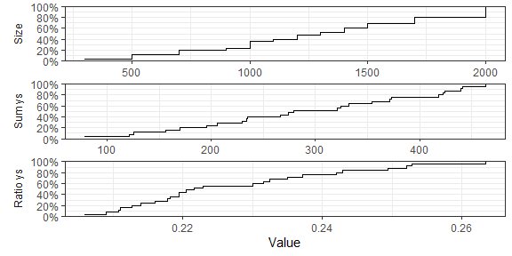

```r
plot_metrics_ecdf(trial_res_mult)
```

Note that all `adaptr` plotting functions require the `ggplot2` package.

The stability of performance metrics according to the number of simulations may be assessed visually using the `plot_convergence()` function.

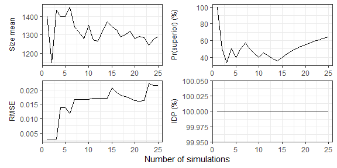

```r
# Convergence plots for four performance metrics
plot_convergence(trial_res_mult, metrics = c("size mean", "prob superior",
                                             "rmse", "idp"))
```

It is seen that the low number of simulations used in this example leads to substantial uncertainty and instability in performance metrics (while the ideal design percentage is always at 100% here, it would likely drop somewhat if more simulations were conducted).

Finally, all combinations of remaining arms after trial completion may be summarised using `check_remaining_arms()`:

```r
check_remaining_arms(trial_res_mult)
```

```
#>     arm_Arm A   arm_Arm B arm_Arm C  n prop        se     lo_ci     hi_ci
#> 1                superior           16 0.64 0.1200000 0.4048043 0.8751957
#> 2 equivalence equivalence            5 0.20 0.1788854 0.0000000 0.5506090
```

### Visualise trial results

In addition to the convergence plots, results may be visualised using the `plot_status()` and `plot_history()` functions. We need non-sparse results for `plot_history()` (but *not* for `plot_status()` or `plot_convergence()` presented above), so we re-run `run_trials()` with the `sparse` argument set to `FALSE`:

```r
trial_res_mult <- run_trials(binom_trial, n_rep = 25, base_seed = 67890,
                             sparse = FALSE)
```

First, we plot the overall trial statuses according to the total number of patients randomised (this function does *not* require `sparse = FALSE`):

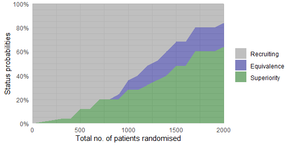

```r
plot_status(trial_res_mult, x_value = "total n")
```

We can also plot the statuses for specific arms, or for all arms if supplying `NA` to the `arm`-argument:

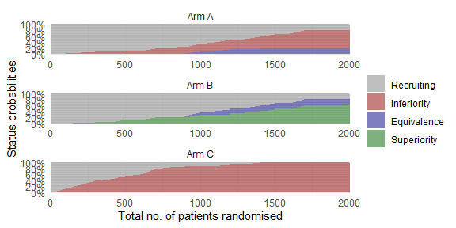

```r
plot_status(trial_res_mult, x_value = "total n", arm = NA, ncol = 1)
```

Next, we plot the history of allocation probabilities at each adaptive analysis look. Intervals cover the inter-quartile range by default (`interval_width = 0.5`):

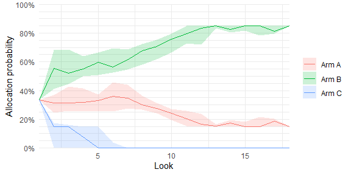

```r
plot_history(trial_res_mult)
```

Plotting other summary metrics is possible; see the `plot_history()` documentation.

## Citation

If using the package, please consider citing:

```r
citation(package = "adaptr")
```

```
#>
#>
#>   Granholm A, Jensen AKG, Lange T, Kaas-Hansen BS (2022). adaptr: an R
#>   package for simulating and comparing adaptive clinical trials.
#>   Journal of Open Source Software, 7(72), 4284. URL
#>   https://doi.org/10.21105/joss.04284.
#>
#> A BibTeX entry for LaTeX users is
#>
#>   @Article{,
#>     title = {{adaptr}: an R package for simulating and comparing adaptive clinical trials},
#>     author = {Anders Granholm and Aksel Karl Georg Jensen and Theis Lange and Benjamin Skov Kaas-Hansen},
#>     journal = {Journal of Open Source Software},
#>     year = {2022},
#>     volume = {7},
#>     number = {72},
#>     pages = {4284},
#>     url = {https://doi.org/10.21105/joss.04284},
#>     doi = {10.21105/joss.04284},
#>   }
```